# データ解析論II第13講

後藤 晶

# 講義資料

## 今日の資料はコチラから．

[figure not shown]

スマホで見る方は**QRコード**を読み込んでください

- 【第1講】イントロダクション
- 【第2講】前期の復習（一般線形モデル）
- 【第3講】一般化線形モデル①
- 【第4講】一般化線形モデル②，一般線形混合モデル
- 【第5講】一般化線形混合モデル- 因子分析①
- 【第6講】因子分析① 因子分析②
- 【第7講】因子分析②
- 【第8講】パス解析
- 【第9講】構造方程式モデリング
- 【第10講】機械学習①：分類
- 【第11講】機械学習②：サポートベクターマシンによる分類
- 【第12講】マッチング法・回帰不連続デザイン
- 【第13講】操作変数法・差の差の分析
- 【第14講】**演習・振り返り**

### radiantの起動

```r
# library(radiant)
# radiant()
```

## 前回の復習

### 因果推論：原因と結果の関係，因果関係を明らかにするための手法

- いわゆる回帰分析やロジスティック回帰分析でやってきたことは「相関関係」を明らかにするのであって，因果関係はわからない．
  - でも，ホントは因果関係を知りたいことが多い．
- 因果関係を明らかにするには「実験」が採用の手段
  - 世の中実験ができれば最高！
  - しかし，必ずしも実験ができないこともたくさんある．．．

[今日のテキスト](https://elib.maruzen.co.jp/elib/html/Viewer/Id/3000040168?8#)

- 明治大学e-libより
- 学内orVPNで学内ネットワークに繋がった状態で確認してください．

### RCT：ランダム化比較実験

- これができれば最高
- 実験群と操作群に分けて影響を検討する
  - [参考](https://www.rieti.go.jp/jp/columns/s18_0009.html)
  - 実験的な介入ができれば良いけど，できないことも多い．

### マッチング法

#### データの読み込み

**[データ](https://akrgt.github.io/2019DA/data/wage_training.csv)**

```r
wage_training <- read_csv("../data/wage_training.csv")
head(wage_training)
```

```
## # A tibble: 6 x 4
##   wagea     T years wageb
##   <dbl> <dbl> <dbl> <dbl>
## 1    19     1     4    18
## 2    27     0    22    27
## 3    20     1     2    18
## 4    36     1    14    34
## 5    28     0     6    28
## 6    18     0     4    18
```

- wagea：研修後の平均年収
- T：研修の参加有無(0：なし，1：あり)
- years：経験年数
- wageb：研修以前の平均年収

#### トリートメントとコントロールの比較

```r
sum(wage_training$T*wage_training$wagea)/sum(wage_training$T) - sum((1-wage_training$T)*wage_training$wagea)/sum(1-wage_training$T)
```

```
## [1] -1.128488
```

```r
cor(wage_training$T,wage_training$years)
```

```
## [1] -0.1908208
```

```r
cor(wage_training$T,wage_training$wageb)
```

```
## [1] -0.1839177
```

#### パッケージのインストール＆読み込み

```r
# install.packages("Matching", dependencies = T)
library(Matching)
```

### 計算の実行（ユークリッド距離）

```r
NN.Euclid <-  Match(wage_training$wagea, wage_training$T, cbind(wage_training$years, wage_training$wageb), Weight=1)

summary(NN.Euclid)
```

```
##
## Estimate...  1.0474
## AI SE......  0.042
## T-stat.....  24.938
## p.val......  < 2.22e-16
##
## Original number of observations..............  800
## Original number of treated obs...............  238
## Matched number of observations...............  238
## Matched number of observations  (unweighted).  838
```

### 計算の実行（マハラノビス距離）

```r
NN.Mahalanobis <-  Match(wage_training$wagea, wage_training$T, cbind(wage_training$years, wage_training$wageb), Weight=2)

summary(NN.Mahalanobis)
```

```
##
## Estimate...  1.0429
## AI SE......  0.047072
## T-stat.....  22.155
## p.val......  < 2.22e-16
##
## Original number of observations..............  800
## Original number of treated obs...............  238
## Matched number of observations...............  238
## Matched number of observations  (unweighted).  883
```

```r
exact_matching <-  Match(wage_training$wagea, wage_training$T, cbind(wage_training$years, wage_training$wageb), exact = TRUE)

summary(exact_matching)
```

```
##
## Estimate...  1.0439
## AI SE......  0.045154
## T-stat.....  23.12
## p.val......  < 2.22e-16
##
## Original number of observations..............  800
## Original number of treated obs...............  238
## Matched number of observations...............  204
## Matched number of observations  (unweighted).  738
##
## Number of obs dropped by 'exact' or 'caliper'  34
```

### 回帰不連続デザイン

#### データの読み込み

**[データ](https://akrgt.github.io/2019DA/data/scholarship.csv)**

```r
scholarship <- read_csv("../data/scholarship.csv")
head(scholarship)
```

```
## # A tibble: 6 x 2
##     GPA   inc
##   <dbl> <dbl>
## 1  1.70   615
## 2  2.28   731
## 3  1.45   510
## 4  3.28   934
## 5  2.20   336
## 6  1.45   269
```

- GPA：成績評価
- inc：家計年収

#### パッケージのインストール＆読み込み

```r
# install.packages("rdd", dependencies = T)
library(rdd)
```

#### 数字の整理

```r
scholarship$inc100 <- -scholarship$inc/100
```

#### 散布図の作成

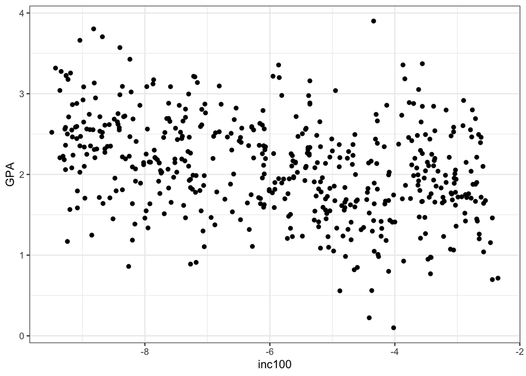

```r
library(ggplot2)
graph <- ggplot(scholarship, aes(x = inc100, y = GPA)) +
  geom_point() +
  theme_bw()
graph
```

* 回帰不連続デザインの最初には必ず散布図を確認する

#### 強制変数の影響を確認

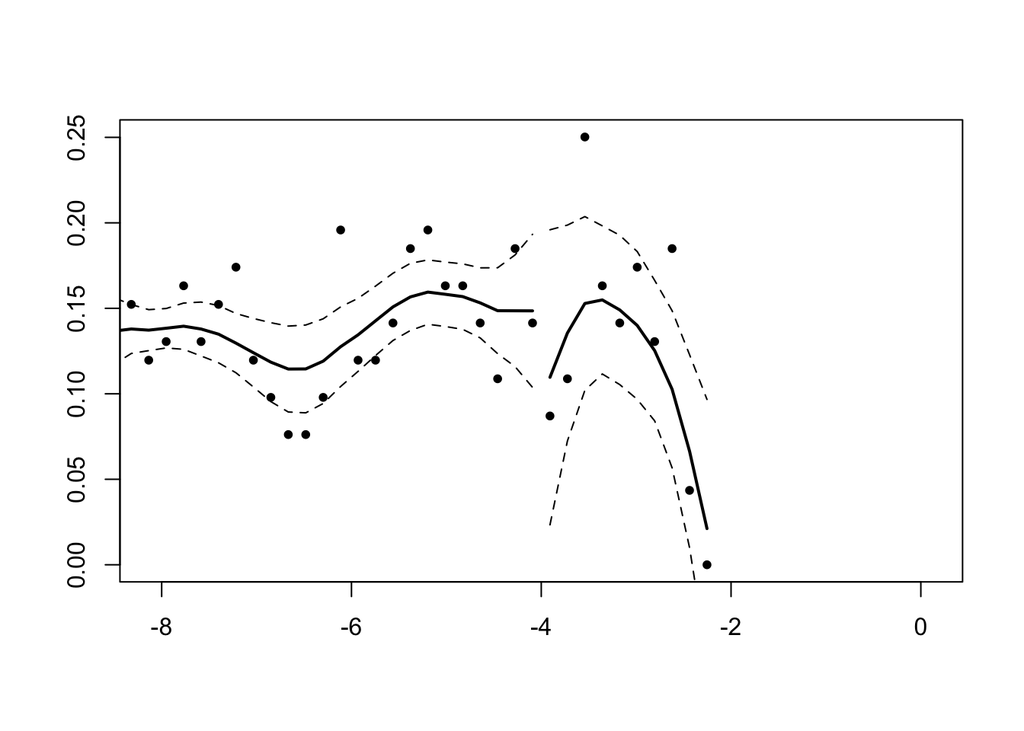

```r
p <-DCdensity(scholarship$inc100, -4, plot=TRUE)
```

```r
p
```

```
## [1] 0.2248964
```

- p値は十分大きいので，強制変数の影響は気にしなくて良い．

#### 局所回帰分析

```r
results<-RDestimate(GPA ~ inc100,scholarship, cutpoint = -4, kernel = "rectangular")
```

#### 結果の確認

```r
summary(results)
```

```
##
## Call:
## RDestimate(formula = GPA ~ inc100, data = scholarship, cutpoint = -4,
##     kernel = "rectangular")
##
## Type:
## sharp
##
## Estimates:
##            Bandwidth  Observations  Estimate  Std. Error  z value
## LATE       3.167      333           0.6079    0.1505      4.038
## Half-BW    1.583      240           0.7207    0.1771      4.068
## Double-BW  6.333      500           0.5273    0.1377      3.829
##            Pr(>|z|)
## LATE       5.391e-05  ***
## Half-BW    4.732e-05  ***
## Double-BW  1.284e-04  ***
## ---
## Signif. codes:  0 '***' 0.001 '**' 0.01 '*' 0.05 '.' 0.1 ' ' 1
##
## F-statistics:
##            F       Num. DoF  Denom. DoF  p
## LATE       11.808  3         329         4.60e-07
## Half-BW     7.643  3         236         1.35e-04
## Double-BW  32.542  3         496         0.00e+00
```

## 演習問題

**[参考資料](https://www.dropbox.com/s/v4qbzruq7sgbazs/text.pdf?dl=0)**

- パスワード：i___c__2_1_da
  - 詳細は授業時に説明します．

#### 1. データセット`exdataset`について，以下の分析を行ってください．

1.1 自然関連項目の5つについて，因子分析を実施し，因子構造を確認してください．

2.2 監視関連項目の5つについて，因子分析を実施し，因子構造を確認してください．

3.3 死後関連項目の5つについて，因子分析を実施し，因子構造を確認してください．

##### 自然関連

以下の質問について4点満点でお答えください．

| 項目名 | データタイトル | 質問項目 | 回答 |
| --- | --- | --- | --- |
| 自然運命 | SPN_UNM | 何かの大きな力に自分の運命は動かされているように感じることがある. | 1全くそう思わない-4非常にそう思う |
| 自然感謝 | SPN_THK | 自然などの人間を超えた力に感謝の気持ちを持つことがある. | 1全くそう思わない-4非常にそう思う |
| 自然恐怖 | SPN_FEA | 自然などの人間を超えた力に恐れの気持ちを持つことがある. | 1全くそう思わない-4非常にそう思う |
| 自然生存 | SPN_LIV | 自然などの人間を超えた力によって，生かされていると思うことがある. | 1全くそう思わない-4非常にそう思う |
| 自然大切 | SPN_IMP | 自然は大切な存在である． | 1全くそう思わない-4非常にそう思う |

##### 監視関連

以下の質問について4点満点でお答えください．

| 項目名 | データタイトル | 質問項目 | 回答 |
| --- | --- | --- | --- |
| 第2者被監視感 | KAN_SEC | 日常生活の中で，直接誰か（人間）に見られていると思うことがある． | 1全くそう思わない-4非常にそう思う |
| 第3者被監視感 | KAN_THI | 日常生活の中で，監視カメラ等を通じて誰か（人間）に間接的に見られていると思うことがある． | 1全くそう思わない-4非常にそう思う |
| 超自然的被監視感 | KAN_SUP | 日常生活の中で，超自然的な存在に見られていると思うことがある． | 1全くそう思わない-4非常にそう思う |
| パレイドリア | KAN_PRD | 無機物の中に，人間の表情のようなものを見出すことがある． | 1全くそう思わない-4非常にそう思う |
| 共感 | KAN_KYK | 人に対して共感をすることがある． | 1全くそう思わない-4非常にそう思う |

##### 死後

以下の質問について4点満点でお答えください．

| 項目名 | データタイトル | 質問項目 | 回答 |
| --- | --- | --- | --- |
| 死後世界 | DED_SHI | 「死後の世界」が存在すると思いますか？ | 1全くそう思わない-4非常にそう思う |
| 天国 | DED_TEN | 「天国」が存在すると思いますか？ | 1全くそう思わない-4非常にそう思う |
| 地獄 | DED_JIG | 「地獄」が存在すると思いますか？ | 1全くそう思わない-4非常にそう思う |
| 奇跡 | DED_KIS | 「奇跡」が存在すると思いますか？ | 1全くそう思わない-4非常にそう思う |
| 天罰 | DED_PUN | 「天罰」が存在すると思いますか？ | 1全くそう思わない-4非常にそう思う |

#### 2. 以下データセットclass_dataには，以前「不確実性下の人間行動」の講義を履修している学生を対象とした調査の結果が入っている．これについて，以下の分析を行うこと

**class_data.csv**

1. 一般的信頼尺度について，因子としての妥当性を確認してください．
2. 一般的信頼尺度の合計得点を算出し，男女差を算出せよ
3. 情報処理スタイル尺度について，因子としての妥当性を確認してください．
4. 情報処理スタイル尺度について，それぞれ2因子についての合計得点を算出し，男女差を算出せよ
5. システム1およびシステム2を外生変数，一般的信頼尺度を内生変数とした構造方程式モデリングによる分析を行ってください．
6. データ列名`crt`は簡易IQテストであるCognitive Refrection Testのスコアを反映しているものである．これについて，システム1およびシステム2を外生変数，crtを内生変数とした構造方程式モデリングによる分析を行ってください．

```r
library(DT)
library(readr)
class_data <- read_csv("/Users/akira/Dropbox/Education/2019MEIJI/[3_Wed2]Data_Analytics/analysis/data/class_data.csv")
DT::datatable(class_data)
```

|  | participant.code | participant.label | Trust1_SNS | Trust2_SNS | Trust3_SNS | Trust4_SNS | Trust5_SNS | Trust6_SNS | Trust7_SNS | Trust1_location | Trust2_location | Trust3_location | Trust4_location | Trust5_location | Trust6_location | Trust7_location | Trust1_phistory | Trust2_phistory | Trust3_phistory | Trust4_phistory | Trust5_phistory | Trust6_phistory | Trust7_phistory | Trust1_telcom | Trust2_telcom | Trust3_telcom | Trust4_telcom | Trust5_telcom | Trust6_telcom | … |
| --- | --- | --- | --- | --- | --- | --- | --- | --- | --- | --- | --- | --- | --- | --- | --- | --- | --- | --- | --- | --- | --- | --- | --- | --- | --- | --- | --- | --- | --- | --- |
| 1 | sgjacrnx | 1810160448 | 0 | 0 | 0 | 0 | 5 | 0 | 0 | 0 | 0 | 0 | 0 | 5 | 0 | 0 | 60 | 60 | 60 | 45 | 70 | 20 | 55 | 5 | 10 | 9 | 4 | 16 | 0 | … |
| 2 | 6rnh5qnn | 1810170413 | 60 | 30 | 50 | 60 | 70 | 30 | 50 | 30 | 15 | 30 | 15 | 15 | 0 | 15 | 80 | 40 | 34 | 70 | 34 | 0 | 60 | 60 | 34 | 10 | 40 | 60 | 14 | … |
| 3 | 3pmd5hop | 1810160380 | 0 | 0 | 0 | 0 | 0 | 50 | 0 | 40 | 20 | 0 | 0 | 40 | 0 | 0 | 70 | 0 | 0 | 0 | 0 | 0 | 0 | 0 | 0 | 0 | 0 | 0 | 0 | … |
| 4 | b61psx1g | 1810170102 | 0 | 0 | 0 | 0 | 0 | 0 | 0 | 30 | 27 | 50 | 27 | 44 | 0 | 50 | 20 | 39 | 40 | 9 | 15 | 20 | 40 | 0 | 20 | 30 | 0 | 0 | 0 | … |
| 5 | rlm7hlmq | 1810160459 | 40 | 50 | 36 | 33 | 72 | 0 | 68 | 0 | 26 | 11 | 0 | 22 | 0 | 32 | 17 | 50 | 25 | 66 | 64 | 0 | 50 | 5 | 29 | 15 | 10 | 50 | 0 | … |
| 6 | xohp14u9 | 1810170286 | 0 | 16 | 10 | 50 | 51 | 70 | 10 | 0 | 19 | 50 | 0 | 0 | 0 | 50 | 70 | 50 | 15 | 50 | 71 | 0 | 18 | 0 | 11 | 30 | 40 | 50 | 0 | … |
| 7 | ur36i7l8 | 1810170438 | 0 | 0 | 0 | 0 | 0 | 0 | 0 | 0 | 0 | 0 | 0 | 0 | 0 | 0 | 0 | 0 | 0 | 0 | 0 | 0 | 0 | 0 | 0 | 0 | 0 | 0 | 0 | … |
| 8 | qwwiu5xx | 1810170164 | 30 | 20 | 30 | 20 | 30 | 0 | 30 | 0 | 0 | 0 | 0 | 0 | 0 | 0 | 50 | 30 | 30 | 30 | 40 | 0 | 30 | 0 | 0 | 20 | 0 | 30 | 0 | … |
| 9 | 2izf5r8u | 1810170387 | 0 | 0 | 50 | 0 | 0 | 29 | 20 | 0 | 0 | 50 | 0 | 0 | 0 | 16 | 25 | 50 | 72 | 50 | 77 | 0 | 76 | 0 | 0 | 0 | 0 | 0 | 0 | … |
| 10 | c8gmzche | 1810170439 | 10 | 20 | 60 | 10 | 60 | 0 | 20 | 10 | 50 | 20 | 10 | 60 | 0 | 10 | 33 | 27 | 50 | 50 | 34 | 3 | 1 | 10 | 20 | 20 | 15 | 20 | 10 | … |

[output cut: 172 more lines]

- 一般的信頼尺度
  - Trust1_gen：ほとんどの人は基本的に正直である
  - Trust2_gen：私は人を信頼するほうである
  - Trust3_gen：ほとんどの人は基本的に善良で親切である
  - Trust4_gen：ほとんどの人は他人を信頼している
  - Trust5_gen：ほとんどの人は信用できる
  - 逆転項目なし
- REI日本語版：情報処理スタイル尺度，直観的処理と合理的処理における個人差を明らかにする尺度（内藤et.al, 2004）
  - Epstein et. al（1996）のREI(Rational Experiential Inventory)の日本語版
- 短縮版を採用
- 直観・感情的な反応を示すシステム1と論理・理性的な思考をもたらすシステム2を反映
  - Kahneman, 2012; Evans, 2010
- **[参考資料①](https://www.jstage.jst.go.jp/article/personality/13/1/13_1_67/_pdf/-char/ja)**

| 逆転項目 | 短縮版 | 順番 | 項目 |
| --- | --- | --- | --- |
|  | ＊ | 1 | たいていの人より，ものごとを論理的に解決するのが上手である． |
| ＊ | ＊ | 2 | 直観に頼らなければならない状況は好きではない． |
|  | ＊ | 3 | 自分の予感を信じることにしている． |
|  | ＊ | 4 | 論理的な考えの持ち主だ． |
| ＊ | ＊ | 5 | ものごとを注意深く理論的に解決するのは，得意ではない． |
|  | ＊ | 6 | 簡単な問題より複雑な問題の方が好きだ． |
|  | ＊ | 7 | なぜだか理由を説明できないが，その人が正しいか間違っているかを，感じとることができる． |
| ＊ | ＊ | 8 | 分析的に考える方ではない． |
| ＊ | ＊ | 9 | 私にはすごい直観力はない． |
| ＊ | ＊ | 10 | 考えることは，楽しいことだと思わない． |
|  | ＊ | 11 | 直観は問題を解決するのに役立つ方法だろう． |
| ＊ | ＊ | 12 | 感情に基づいて重要な決定をするのは，愚かなことだと思う． |
|  | ＊ | 13 | 行動を決める時，直観に頼ることが多い． |
|  | ＊ | 14 | 私にとって，新しい考え方を学ぶことは，とても魅力的である． |
| ＊ | ＊ | 15 | 複雑な問題を解決するのは，得意ではない． |
|  | ＊ | 16 | 知的な挑戦が好きだ． |
| ＊ | ＊ | 17 | 直観に頼って重要な決定をするのは，いい考えだと思わない． |
| ＊ | ＊ | 18 | もし私が直観に頼るならば，間違いをおかすことが多くなるだろう． |
|  | ＊ | 19 | 直観的な印象に頼るのが好きだ． |
|  | ＊ | 20 | 一生懸命考えなければならないような問題を解決するのが好きだ． |
|  | ＊ | 21 | 答えを見つけるために直観に従って，うまくいかなかったことはほとんどない． |
|  | ＊ | 22 | 人生や生活上のいろんな問題を考えるとき，直観的にやるとうまくいく． |
| ＊ | ＊ | 23 | 注意深く論理的な分析が必要とされる問題を解決するのは，得意ではない． |
| ＊ | ＊ | 24 | いろいろ考えるのは好きではない． |

# 資料

## Rでデータを扱う時に注意すべきこと

- 必ず数字／文字は半角で入力する．
- 日本語は使わずにローマ字を使用する．
- コメントアウト（コードではなく，関係ないメモを入れること）をするときは半角の「#」から始める．
- メモする内容は全角でもよい．
- ファイル名およびパスには決して全角の文字（ひらがな，カタカナ，漢字，全角スペースなど）を入れてはいけない．
- 半角英数字だけにする．
- 慌てずに落ち着いて操作すれば，決して難しくない．
- 1つずつ落ち着いて作業することを心がける．
- 「わからない」ことを恐れない
- 周りの友人に聞いたり，教員に確認したりしよう．

### リアクションペーパー：

- 授業で学んだことおよび感想を下記リンクからお答えください． [リアクションペーパー](https://forms.gle/DqVa7ea9py9biejJ7)

## 参考文献など

### 参考図書（和書）

*統計について*

- [山田剛史, 杉澤武俊, 村井潤一郎, 2008, 『Rによる優しい統計学』, オーム社, *明治e-libへ*](https://elib.maruzen.co.jp/elib/html/BookDetail/Id/3000002659?7)
- 基本的な考え方を紹介してくれる本．oh-o!Meijiにログインすれば無料で読める．
- [内田治, 西澤英子 2008, 『Rによる統計的検定と推定』, オーム社, *明治e-libへ*](https://elib.maruzen.co.jp/elib/html/BookDetail/Id/3000002728?9)
- 基本的な考え方を紹介してくれる本．oh-o!Meijiにログインすれば無料で読める．
- [奥村晴彦 2008, 『Rによる統計的検定と推定』, オーム社, *明治e-libへ*](https://elib.maruzen.co.jp/elib/html/BookDetail/Id/3000002728?9)
- 基本的な考え方を紹介してくれる本．oh-o!Meijiにログインすれば無料で読める．
- [小杉考司, 2019, 『言葉と数式で理解する多変量解析入門』, 北大路出版](https://www.amazon.co.jp/dp/476283047X)
- 非常に平易な言葉で多変量解析について説明がなされている．ただし，一歩戻って基本的RStudioの使い方と基本的な統計(t検定や回帰分析，カイ2乗検定など)を学ぶのであれば，[小杉考司, 2019, 『Rでらくらく心理統計 RStudio徹底活用』](https://www.amazon.co.jp/dp/4065144876)などもよいでしょう．
- [星野匡郎, 田中久稔, 2018, 『Rによる実証分析 ―回帰分析から因果分析へ―』, 裳華房](https://www.amazon.co.jp/dp/427421947X)
- Rを用いた様々な分析手法について記載されている．春学期の内容も含まれるが，主に秋学期の内容をカバーしている．
- [川端一光, 岩間徳兼, 鈴木雅之, 2018, 『Rによる多変量解析入門 - データ解析の実践と理論』, オーム社](https://www.amazon.co.jp/dp/4274222365/)
- 基本的な技術を学ぶことができる．かなり良書．
- *この講義の作成にかなり使っています．*
  - [森田果, 2014, 『実証分析入門 - データから「因果関係」を読み解く作法』, 日本評論社](https://www.amazon.co.jp/dp/4535557934)
- 法律系の先生が書かれた本だが，なかなかわかりやすく面白い．どちらかというと秋学期の内容に関わる．
- [地道正行, 2018, 『データサイエンスの基礎 Rによる統計学独習』, 裳華房](https://www.amazon.co.jp/dp/4785315784)
- 細かく書かれているが，数式も多い．講義内で数学的説明の時間を十分に確保できないため，興味のある方はこちらへ．

*再現性の議論について*

- [高橋康介, 2018, 『再現可能性のすゝめ (Wonderful R 3)』, 共立出版](https://www.amazon.co.jp/dp/4320112431)
- [江口哲史(編), 2018『自然科学研究のためのR入門―再現可能なレポート執筆実践― (Wonderful R 4)』, 共立出版](https://www.amazon.co.jp/dp/432011244X)
- いずれの本も再現可能性のためにRStudioとRMarkdownの使い方について紹介した本．

*分析の一連の流れについて*

- [岩波データサイエンス](https://elib.maruzen.co.jp/elib/html/SeriesDetail/Id/3000047689?28)
- 様々な応用的な統計の考え方を紹介している．
- [松村優哉, 湯谷啓明, 紀ノ定保礼, 前田和寛, 2018, 『RユーザのためのRStudio[実践]入門−tidyverseによるモダンな分析フローの世界』, 技術評論社](https://www.amazon.co.jp/dp/4774198536/)
- RStudioを用いたデータ収集，データ整形，可視化，レポーティングといった一連の分析の流れに関する本．

### 参考図書（洋書）

*計量経済について* * [Heiss, Florian, 2016, “Using R for Introductory Econometrics”, Amazon Digital Services](https://www.amazon.co.jp/dp/1523285133/) - 洋書．Rを用いた計量経済学入門の教科書だが，手を動かしながら学んでいくことができる．

### 参考web資料

*Rによる統計* * [Rjpwiki](http://www.okadajp.org/RWiki/) - Rに関する基礎知識の共有などが図られている．

- r-wakalang
- Slackのグループ．全く知らない人たちが色々質問に答えてくれたりも．
- [からだにいいもの](https://www.karada-good.net)
- Rに関する様々な情報が掲載されている．多少応用的なトピックが多い．
- [marketechlabo](https://www.marketechlabo.com/r-best-packages/)
- ちょっと新しいパッケージ等が紹介されていて興味深い

*RMarkdownの使い方*

- [R Markdown入門](https://kazutan.github.io/kazutanR/Rmd_intro.html)
- Rマークダウンに限らずデータ操作や可視化などの技術についても[他ページ](https://kazutan.github.io/kazutanR/index.html)で紹介している．
- [R Markdownで楽々レポートづくり](http://gihyo.jp/admin/serial/01/r-markdown/0001)
- 全8話のRMarkdownの操作方法について．この記事の内容は[高橋康介, 2014, 『ドキュメント・プレゼンテーション生成 (シリーズ Useful R 9)』, 共立出版](https://www.amazon.co.jp/dp/4320123727)をもとに作成されている．しかし，この記事を読めばよく分かる．．．

## データの概要

### データの頭10個

```r
library(DT)
library(readr)
exdataset <- read_csv("/Users/akira/Dropbox/Education/2019MEIJI/[3_Wed2]Data_Analytics/analysis/data/exdataset.csv")
DT::datatable(exdataset)
```

|  | SUB_HAP | SUB_SAT | SUB_SLP | DIC_PAR | DIC_FRI | DIC_OTH | ULT_PRO_PAR | ULT_PRO_FRI | ULT_PRO_OTH | ULT_REC_PAR | ULT_REC_FRI | ULT_REC_OTH | TRU_PAR | TRU_FRI | TRU_OTH | SPN_UNM | SPN_THK | SPN_FEA | SPN_LIV | SPN_IMP | KAN_SEC | KAN_THI | KAN_SUP | KAN_PRD | KAN_KYK | DED_SHI | DED_TEN | DED_JIG | DED_KIS | … |
| --- | --- | --- | --- | --- | --- | --- | --- | --- | --- | --- | --- | --- | --- | --- | --- | --- | --- | --- | --- | --- | --- | --- | --- | --- | --- | --- | --- | --- | --- | --- |
| 1 | 4 | 4 | 9 | 10 | 5 | 3 | 10 | 5 | 5 | 0 | 1 | 1 | 10 | 5 | 3 | 1 | 3 | 3 | 3 | 4 | 1 | 2 | 1 | 2 | 3 | 1 | 1 | 1 | 3 | … |
| 2 | 6 | 5 | 8 | 3 | 1 | 0 | 3 | 5 | 7 | 3 | 5 | 5 | 2 | 1 | 0 | 2 | 3 | 3 | 2 | 3 | 3 | 3 | 2 | 2 | 3 | 2 | 2 | 2 | 3 | … |
| 3 | 5 | 3 | 3 | 10 | 5 | 0 | 10 | 5 | 0 | 10 | 5 | 0 | 10 | 5 | 0 | 2 | 3 | 3 | 2 | 3 | 3 | 3 | 3 | 2 | 2 | 3 | 2 | 2 | 3 | … |
| 4 | 5 | 5 | 4 | 2 | 0 | 0 | 5 | 5 | 5 | 5 | 5 | 5 | 2 | 2 | 2 | 4 | 3 | 3 | 3 | 3 | 2 | 2 | 4 | 4 | 3 | 2 | 2 | 2 | 3 | … |
| 5 | 3 | 3 | 2 | 0 | 0 | 0 | 5 | 5 | 0 | 5 | 5 | 0 | 10 | 10 | 1 | 1 | 2 | 3 | 3 | 3 | 1 | 1 | 1 | 1 | 3 | 4 | 4 | 4 | 2 | … |
| 6 | 7 | 7 | 6 | 3 | 1 | 0 | 3 | 1 | 0 | 3 | 1 | 0 | 5 | 3 | 0 | 3 | 3 | 3 | 3 | 3 | 3 | 3 | 2 | 3 | 3 | 3 | 3 | 3 | 3 | … |
| 7 | 5 | 5 | 6 | 5 | 2 | 0 | 5 | 3 | 2 | 0 | 1 | 1 | 10 | 5 | 0 | 2 | 2 | 2 | 2 | 3 | 3 | 3 | 1 | 3 | 4 | 4 | 2 | 4 | 2 | … |
| 8 | 5 | 5 | 8 | 5 | 5 | 0 | 5 | 5 | 0 | 5 | 5 | 0 | 5 | 8 | 0 | 4 | 4 | 4 | 4 | 3 | 4 | 4 | 4 | 3 | 3 | 3 | 3 | 3 | 3 | … |
| 9 | 1 | 3 | 1 | 10 | 5 | 0 | 10 | 5 | 0 | 10 | 5 | 0 | 10 | 8 | 4 | 3 | 4 | 4 | 4 | 4 | 3 | 1 | 1 | 1 | 3 | 3 | 3 | 3 | 4 | … |
| 10 | 7 | 7 | 5 | 5 | 5 | 0 | 5 | 5 | 5 | 5 | 5 | 0 | 3 | 3 | 0 | 2 | 3 | 3 | 3 | 3 | 2 | 2 | 2 | 2 | 3 | 2 | 2 | 2 | 3 | … |

[output cut: 953 more lines]

### 変数名リスト

#### 主観的指標

| 項目名 | データタイトル | 質問項目 | 回答 |
| --- | --- | --- | --- |
| 主観的幸福度 | SUB_HAP | 現在，あなたはどの程度幸せですか？「とても幸せ」を10点，「とても不幸せ」を0点とすると，何点くらいになると思いますか？* | 0点「とても不幸せ」-10点「とても幸せ」 |
| 生活満足度 | SUB_SAT | あなたは全体として最近の生活にどの程度満足していますか？「とても満足」を10点，「とても不満足」を0点とすると，何点くらいになると思いますか？ | 0点「とても不満足」-10点「とても満足」 |
| 睡眠満足度 | SUB_SLP | あなたは最近，どの程度眠れていますか？「とても眠れている」を10点，「全く眠れていない」を0点とすると，何点くらいになると思いますか？ | 0点「全く眠れていない」-10点「とても眠れている」 |

#### 独裁者ゲーム

図を見て下さい.  
あなたはAさんです. あなたはTポイントを10ポイントを受け取りました.  
そのうち，あなたはBさんに何ポイントかを渡すことができます．  
さて，あなたはBさんに何ポイント渡しますか？  
ここでは以下の条件の場合について教えて下さい.

| 項目名 | データタイトル | 質問項目 | 回答 |
| --- | --- | --- | --- |
| 主観的幸福度 | DIC_PAR | Bさんが両親の場合 | 0ポイント-10ポイント |
| DG友人条件 | DIC_FRI | Bさんが友人の場合 | 0ポイント-10ポイント |
| DG他者条件 | DIC_OTH | Bさんが全く知らない他人の場合 | 0ポイント-10ポイント |

#### 最終提案ゲーム_提案者

図を見て下さい.  
あなたはAさんです. あなたはTポイントを10ポイントを受け取りました.  
そのうち，あなたはBさんとポイントを分け合うことになりました．  
あなたは，Bさんに対して分け合うポイントを提案することができます．  
あなたは，10ポイントの中から，Bさんに対して分けたポイントを引いた残りを受け取ることができます．  
しかし，Bさんがあなたの提案を拒否した場合には，その提案は実現せずに，  
お互いポイントをもらえないことになります．  
さて，あなたはBさんに何ポイント渡すことを提案しますか？  
ここでは以下の条件の場合について教えて下さい.

| 項目名 | データタイトル | 質問項目 | 回答 |
| --- | --- | --- | --- |
| 最終提案提案者両親条件 | ULT_PRO_PAR | Bさんが両親の場合 | 0ポイント-10ポイント |
| 最終提案提案者友人条件 | ULT_PRO_FRI | Bさんが友人の場合 | 0ポイント-10ポイント |
| 最終提案提案者他者条件 | ULT_PRO_OTH | Bさんが全く知らない他人の場合 | 0ポイント-10ポイント |

#### 最終提案ゲーム_応答者

図を見て下さい. あなたはBさんです. AさんはTポイントを10ポイントを受け取りました.  
Aさんが，あなたに対して分け合うポイントを提案します．  
Aさんは，10ポイントの中から，あなたに対して分けたポイントを引いた残りを受け取ることができます．  
しかし，あなたがAさんの提案を拒否した場合には，その提案は実現せずに，  
お互いポイントをもらえないことになります．  
さて，最低でも何ポイントの提案を受けたら，Aさんの提案を受け入れますか？  
ここでは以下の条件の場合について教えて下さい.

| 項目名 | データタイトル | 質問項目 | 回答 |
| --- | --- | --- | --- |
| 最終提案応答者両親条件 | ULT_REC_PAR | Bさんが両親の場合 | 0ポイント-10ポイント |
| 最終提案応答者友人条件 | ULT_REC_FRI | Bさんが友人の場合 | 0ポイント-10ポイント |
| 最終提案応答者他者条件 | ULT_REC_OTH | Bさんが全く知らない他人の場合 | 0ポイント-10ポイント |

#### 信頼ゲーム

図を見て下さい.  
あなたはAさんです. あなたはTポイントを10ポイント持っています.  
いくらかをCさんにあずけてください. CさんはあなたからあずかったTポイントを3倍にしてBさんに渡します.  
Bさんは手元に渡されたポイントのうち，いくらかをあなたに返します.  
この時，あなたはCさんにいくらあずけますか？  
ここではBさんが以下の条件の場合について教えて下さい.

| 項目名 | データタイトル | 質問項目 | 回答 |
| --- | --- | --- | --- |
| 信頼両親条件 | TRU_PAR | Bさんが両親の場合 | 0ポイント-10ポイント |
| 信頼友人条件 | TRU_FRI | Bさんが友人の場合 | 0ポイント-10ポイント |
| 信頼他者条件 | TRU_OTH | Bさんが全く知らない他人の場合 | 0ポイント-10ポイント |

#### 自然関連

以下の質問について4点満点でお答えください．

| 項目名 | データタイトル | 質問項目 | 回答 |
| --- | --- | --- | --- |
| 自然運命 | SPN_UNM | 何かの大きな力に自分の運命は動かされているように感じることがある. | 1全くそう思わない-4非常にそう思う |
| 自然感謝 | SPN_THK | 自然などの人間を超えた力に感謝の気持ちを持つことがある. | 1全くそう思わない-4非常にそう思う |
| 自然恐怖 | SPN_FEA | 自然などの人間を超えた力に恐れの気持ちを持つことがある. | 1全くそう思わない-4非常にそう思う |
| 自然生存 | SPN_LIV | 自然などの人間を超えた力によって，生かされていると思うことがある. | 1全くそう思わない-4非常にそう思う |
| 自然大切 | SPN_IMP | 自然は大切な存在である． | 1全くそう思わない-4非常にそう思う |

#### 監視

以下の質問について4点満点でお答えください．

| 項目名 | データタイトル | 質問項目 | 回答 |
| --- | --- | --- | --- |
| 第2者被監視感 | KAN_SEC | 日常生活の中で，直接誰か（人間）に見られていると思うことがある． | 1全くそう思わない-4非常にそう思う |
| 第3者被監視感 | KAN_THI | 日常生活の中で，監視カメラ等を通じて誰か（人間）に間接的に見られていると思うことがある． | 1全くそう思わない-4非常にそう思う |
| 超自然的被監視感 | KAN_SUP | 日常生活の中で，超自然的な存在に見られていると思うことがある． | 1全くそう思わない-4非常にそう思う |
| パレイドリア | KAN_PRD | 無機物の中に，人間の表情のようなものを見出すことがある． | 1全くそう思わない-4非常にそう思う |
| 共感 | KAN_KYK | 人に対して共感をすることがある． | 1全くそう思わない-4非常にそう思う |

#### 死後

以下の質問について4点満点でお答えください．

| 項目名 | データタイトル | 質問項目 | 回答 |
| --- | --- | --- | --- |
| 死後世界 | DED_SHI | 「死後の世界」が存在すると思いますか？ | 1全くそう思わない-4非常にそう思う |
| 天国 | DED_TEN | 「天国」が存在すると思いますか？ | 1全くそう思わない-4非常にそう思う |
| 地獄 | DED_JIG | 「地獄」が存在すると思いますか？ | 1全くそう思わない-4非常にそう思う |
| 奇跡 | DED_KIS | 「奇跡」が存在すると思いますか？ | 1全くそう思わない-4非常にそう思う |
| 天罰 | DED_PUN | 「天罰」が存在すると思いますか？ | 1全くそう思わない-4非常にそう思う |

#### 性行動

以下の質問についてお答えください．

| 項目名 | データタイトル | 質問項目 | 回答 |
| --- | --- | --- | --- |
| 性衝動 | SEX_IMP，SEX_IMP_num（数値，欠損値有り） | あなたの性衝動はどの程度強いと思いますか？7点満点でお答え下さい．なお，答えたくない方は「8.答えたくない」を選んで下さい． | 全く弱い．2. 弱い．3. どちらかと言えば弱い．4. どちらとも言えない．5. どちらかと言えば強い．6. 強い．7. 非常に強い．8. 答えたくない． |
| 自慰回数 | SEX_MAS，SEX_MAS_nen（年間回数）： | あなたはどの程度の頻度でマスターベーションをしていますか？以下の選択肢の中から最も近いものを選んで下さい．なお，答えたくない方は「10. 答えたくない」を選んで下さい． | 1. 経験がない「0」, 2. 年に1回程度「1」, 3. 半年に1回程度「2」, 4. 3ヶ月に1回程度「4」, 5. 1ヶ月に1回程度「12」, 6. 2週に1回程度「26」, 7. 週に1回程度「52」, 8. 週に2-3回程度「130」, 9. 1日に1回程度「365」, 10. それ以上「730」, 11. 答えたくない「NA」 |
| 性交渉回数 | SEX_SEX，SEX_SEX_nen（年間回数） | あなたはどの程度の頻度で性交渉（性行為）をしていますか？以下の選択肢の中から最も近いものを選んで下さい．なお，答えたくない方は「10. 答えたくない」を選んで下さい． | 1. 経験がない「0」, 2. 年に1回程度「1」, 3. 半年に1回程度「2」, 4. 3ヶ月に1回程度「4」, 5. 1ヶ月に1回程度「12」, 6. 2週に1回程度「26」, 7. 週に1回程度「52」, 8. 週に2-3回程度「130」, 9. 1日に1回程度「365」, 10. それ以上「730」, 11. 答えたくない「NA」 |
| 性衝動対象 | SEX_OBJ | あなたの性衝動の対象として当てはまる選択肢を選んで下さい．なお，答えたくない方は「5.答えたくない」を選んで下さい． | 1.異性, 2. 同性,3. 両方,4. その他,5. 答えたくない |
| 天罰 | SEX_NIN，SEX_NIN_cen（中央値） | あなたが性交渉（性行為）をしたことがある人数を教えて下さい．* 性交渉を（性行為）したことがない場合は「0. 0人」を選んで下さい． また，答えたくない方は「12.答えたくない」を選んで下さい． | 1. 0人 「0」, 2. 1人 「1」, 3. 2〜3人 「2.5」, 4. 4〜5人 「4.5」, 5. 5〜7人 「6」, 6. 8〜10人 「9」, 7. 11〜15人 「13」, 8. 16〜20人 「18」, 9. 21〜30人 「25.5」, 10. 31〜40人 「35.5」, 11. 41〜100人 「70.5」, 12. 101人以上 「101」, 13. 答えたくない．「NA… |
| 性情報開示 | SEX_NNA | 性情報に対して開示しなかった個数 | 上記5つについて答えたくないを選んだ個数 |

#### フェイスシート

あなたのことについて教えて下さい．

| 項目名 | データタイトル | 質問項目 | 回答 |
| --- | --- | --- | --- |
| 性別 | F_SEX | あなたの性別を教えて下さい. | 1.男性, 2.女性,3.その他 |
| 世代 | F_GEN | あなたの年齢を教えて下さい. | 1. 10代前半, 2. 10代後半, 3. 20代前半, 4. 20代後半, 5. 30代前半, 6. 30代後半, 7. 40代前半, 8. 40代後半, 9. 50代前半, 10. 50代前半, 11. 60代前半, 12. 60代後半, 13. 70代以降 |
| 最終学歴 | F_FGR | あなたの最終学歴を教えて下さい. | 1. 中学校卒業, 2. 高校中退, 3. 高校卒業, 4. 専門学校（短期大学）中退, 5. 専門学校（短期大学）卒業, 6. 大学中退, 7. 大学卒業, 8. 大学院修士課程（博士前期課程）中退, 9. 大学院修士課程（博士前期課程）修了, 10. 大学院博士課程（博士後期課程）中退, 11. 大学院博士課程（博士後期課程）修了 |
| 個人収入 | F_INK，F_INK_cen(中央値，百万円) | あなた個人の年収を教えて下さい. | 0. 0円, 1. 1円〜200万円未満, 2. 200万円以上〜400万円未満, 3. 400万円以上〜600万円未満, 4. 600万円以上〜800万円未満, 5. 800万円以上〜1,000万円未満, 6. 1,000万円以上〜1,200万円未満, 7. 1,200万円以上〜1,500万円未満, 8. 1,500万円以上〜2,000万円未満, 9. 2,000万円以上, 10. わからない |
| 世帯収入 | F_INS，F_INS_cen(中央値，百万円) | あなたの世帯での収入の合計を教えて下さい. | 0. 0円, 1. 1円〜200万円未満, 2. 200万円以上〜400万円未満, 3. 400万円以上〜600万円未満, 4. 600万円以上〜800万円未満, 5. 800万円以上〜1,000万円未満, 6. 1,000万円以上〜1,200万円未満, 7. 1,200万円以上〜1,500万円未満, 8. 1,500万円以上〜2,000万円未満, 9. 2,000万円以上, 10. わからない |
| 回答端末 | F_TAN | あなたが現在回答に使われているケータイ／タブレット／パソコンについて，当てはまるものを選んで下さい． | 1. パソコン（Windows）, 2. パソコン（Mac）, 3. パソコン（その他）, 4. タブレット（Windows）, 5. タブレット（iOS，iPad）, 6. タブレット（android）, 7. タブレット（その他）, 8. スマホ（Windows）, 9. スマホ（iOS，iPhone）, 10. スマホ（android）, 11. スマホ（その他）, 12. ガラケー，フィー… |
| 都道府県 | PRE | あなたのお住まいの県を教えて下さい. | 1. 北海道2. 青森県3. 岩手県4. 宮城県5. 秋田県6. 山形県7. 福島県8. 茨城県9. 栃木県10. 群馬県11. 埼玉県12. 千葉県13. 東京都14. 神奈川県15. 新潟県16. 富山県17. 石川県18. 福井県19. 山梨県20. 長野県21. 岐阜県22. 静岡県23. 愛知県24. 三重県25. 滋賀県26. 京都府27. 大阪府28. 兵庫県29. 奈良県30. 和… |
| 地域 | ARE | 都道府県から地域に変換 | 北海道：1. 北海道，東北地方：2. 青森県3. 岩手県4. 宮城県5. 秋田県6. 山形県7. 福島県，関東地方：8. 茨城県9. 栃木県10. 群馬県11. 埼玉県12. 千葉県13. 東京都14. 神奈川県，中部地方：15. 新潟県16. 富山県17. 石川県18. 福井県19. 山梨県20. 長野県21. 岐阜県22. 静岡県23. 愛知県24. 三重県，近畿地方：25. 滋賀県26. 京… |
| 未既婚 | MAR | あなたはご結婚されていますか？ | NotMarried：未婚，Married：既婚 |
| 子の有無 | CHI | あなたはお子さんがいらっしゃいますか？ | NoChild：いない，Child：いる |